# Etapa 2 — Integración clima-eventos y construcción del panel analítico

Edwin Silva Salas

2026-09-17

# 1. Objetivo del análisis

El objetivo de esta sección es construir una base de datos integrada que combine información climatológica y eventos de falla en una unidad espacial y temporal consistente, con el fin de:

- Consolidar la información en una única estructura analítica
- Garantizar consistencia entre dimensiones espacial y temporal
- Preparar el insumo base para modelos predictivos
- Permitir análisis conjuntos clima–fallas
- Evitar problemas de explosión de datos por joins incorrectos

Unidad de análisis: **cuadrante × semana**.

# 2. Preparación de datos

```r
library(dplyr)
library(ggplot2)
library(lubridate)
library(readr)
library(tidyr)
library(readxl)
```

## Entorno (.env)

```r
buscar_env <- function() {
  candidatos <- c(".env", file.path("..", ".env"), file.path("..", "..", ".env"),
                  file.path("..", "..", "..", ".env"), file.path("..", "..", "..", "..", ".env"))
  existentes <- candidatos[file.exists(candidatos)]
  if (length(existentes) == 0) return(NA_character_)
  existentes[1]
}
ruta_env <- buscar_env()
if (!is.na(ruta_env)) {
  readRenviron(ruta_env)
} else {
  warning("No se encontró un archivo .env. Copia .env.example como .env y ajusta UBICACION_DATA.")
}

UBICACION_DATA <- Sys.getenv("UBICACION_DATA")
if (UBICACION_DATA == "") {
  stop("UBICACION_DATA no esta definida. Verifica el archivo .env.")
}
cat(sprintf("UBICACION_DATA: %s\n", UBICACION_DATA))
```

```
## UBICACION_DATA: D:/OneDrive - PUJ Cali/Projecto_Grado_Javeriana/Data_Project/
```

# 3. Carga de bases consolidadas

Se leen los dos insumos producidos por los documentos anteriores del pipeline (`Etapa2_10_cargue_nasa_semana.Rmd` y `Etapa2_11_cargue_eventos_semana.Rmd`) — **ya no desde una ruta fija de un usuario específico**, sino desde `UBICACION_DATA`.

```r
# Clima semanal con coordenadas
clima_semana_spatial <- readRDS(file.path(UBICACION_DATA, "clima_semana_spatial.rds"))

# Eventos agregados por cuadrante-semana
eventos_cuadrante_semana <- readRDS(file.path(UBICACION_DATA, "eventos_semana_spatial.rds"))
```

# 4. Construcción del panel final

```r
panel_semana <- clima_semana_spatial %>%
  left_join(
    eventos_cuadrante_semana %>% select(-latitud, -longitud),
    by = c("id_cuadrante", "semana")
  ) %>%
  mutate(
    n_eventos = replace_na(n_eventos, 0),
    duracion_total = replace_na(duracion_total, 0),
    duracion_promedio = replace_na(duracion_promedio, 0),
    falla = as.integer(n_eventos > 0)
  )
```

## Exportación del panel

Este es el panel intermedio (clima + eventos, sin las variables de usuarios/estrato/activos de `D_mod`) que consumen los documentos de Etapa 4 (`Etapa4_01_feature_engineering_general.Rmd`, `Etapa4_02_rezagos_SAIDI.Rmd`).

```r
saveRDS(panel_semana, file.path(UBICACION_DATA, "panel_semana.rds"))
cat(sprintf("panel_semana exportado: %d filas x %d columnas\n",
            nrow(panel_semana), ncol(panel_semana)))
```

```
## panel_semana exportado: 90128 filas x 19 columnas
```

# 5. Validación del panel

## 5.1 Dimensiones

```r
dim(panel_semana)
```

```
## [1] 90128    19
```

## 5.2 Valores faltantes

```r
panel_semana %>%
  summarise_all(~sum(is.na(.)))
```

```
## # A tibble: 1 × 19
##   id_cuadrante semana temp_media_semana temp_max_semana temp_min_semana
##          <int>  <int>             <int>           <int>           <int>
## 1            0      0                 0               0               0
## # ℹ 14 more variables: precip_total_semana <int>, humedad_media_semana <int>,
## #   viento_medio_semana <int>, viento_max_semana <int>, lluvia_intensa <int>,
## #   calor_extremo <int>, viento_fuerte <int>, longitud <int>, latitud <int>,
## #   n_eventos <int>, duracion_total <int>, duracion_promedio <int>,
## #   evento_extremo <int>, falla <int>
```

## 5.3 Distribución de la variable objetivo

Clave para entender el desbalance de clases.

```r
table(panel_semana$falla)
```

```
##
##     0     1
## 67467 22661
```

```r
prop.table(table(panel_semana$falla))
```

```
##
##         0         1
## 0.7485687 0.2514313
```

# 6. Análisis exploratorio integrado

## 6.1 Dinámica temporal de fallas

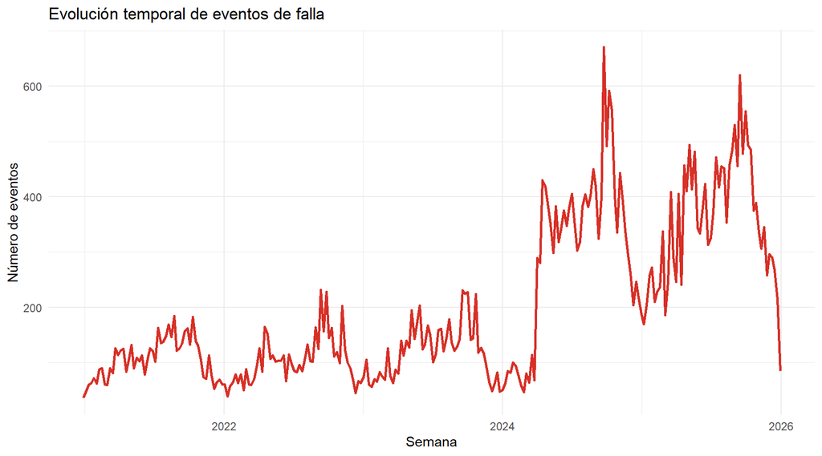

```r
fallas_tiempo <- panel_semana %>%
  group_by(semana) %>%
  summarise(
    total_eventos = sum(n_eventos, na.rm = TRUE),
    proporcion_fallas = mean(falla, na.rm = TRUE),
    .groups = "drop"
  )

ggplot(fallas_tiempo, aes(x = semana, y = total_eventos)) +
  geom_line(color = "#d73027", linewidth = 1) +
  theme_minimal() +
  labs(
    title = "Evolución temporal de eventos de falla",
    x = "Semana",
    y = "Número de eventos"
  )
```

## 6.2 Distribución espacial de fallas

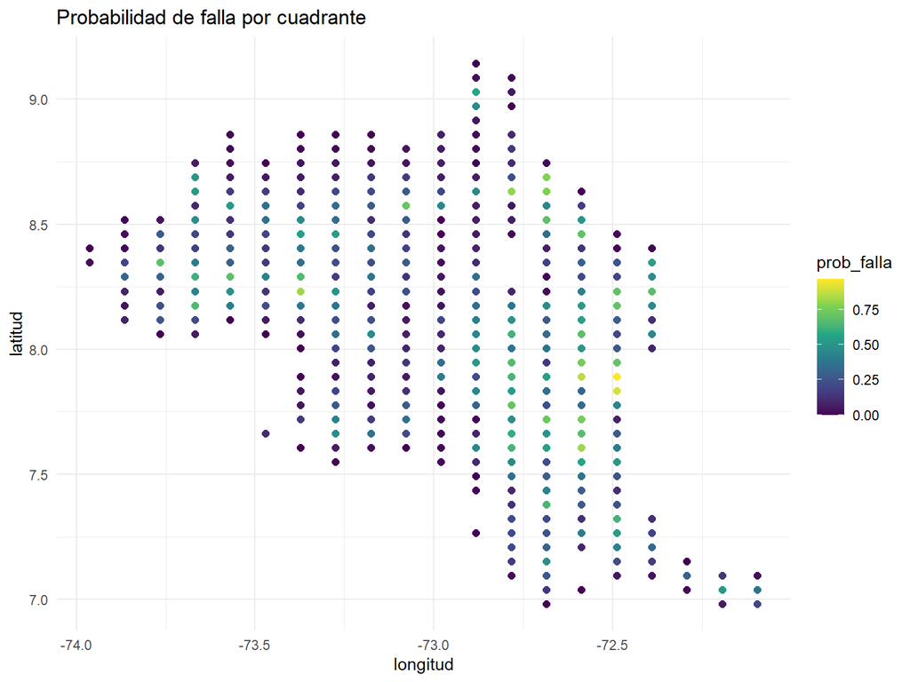

```r
fallas_mapa <- panel_semana %>%
  group_by(id_cuadrante, latitud, longitud) %>%
  summarise(
    eventos_promedio = mean(n_eventos, na.rm = TRUE),
    prob_falla = mean(falla, na.rm = TRUE),
    .groups = "drop"
  )

ggplot(fallas_mapa, aes(x = longitud, y = latitud)) +
  geom_point(aes(color = prob_falla), size = 2) +
  scale_color_viridis_c() +
  theme_minimal() +
  labs(title = "Probabilidad de falla por cuadrante")
```

## 6.3 Relación clima–fallas

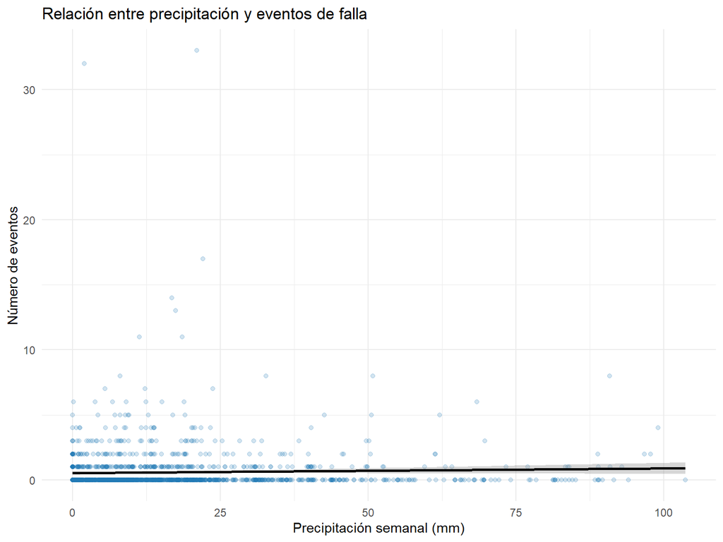

```r
ggplot(panel_semana %>% slice_sample(n = 1500), aes(x = precip_total_semana, y = n_eventos)) +
  geom_point(alpha = 0.2, color = "#1f78b4") +
  geom_smooth(method = "lm", color = "black") +
  theme_minimal() +
  labs(
    title = "Relación entre precipitación y eventos de falla",
    x = "Precipitación semanal (mm)",
    y = "Número de eventos"
  )
```

## 6.4 Eventos extremos y fallas

```r
panel_semana %>%
  group_by(lluvia_intensa) %>%
  summarise(
    promedio_eventos = mean(n_eventos, na.rm = TRUE),
    prob_falla = mean(falla, na.rm = TRUE)
  )
```

```
## # A tibble: 2 × 3
##   lluvia_intensa promedio_eventos prob_falla
##            <int>            <dbl>      <dbl>
## 1              0            0.573      0.250
## 2              1            0.583      0.263
```

## 6.5 Interacción espacio–tiempo

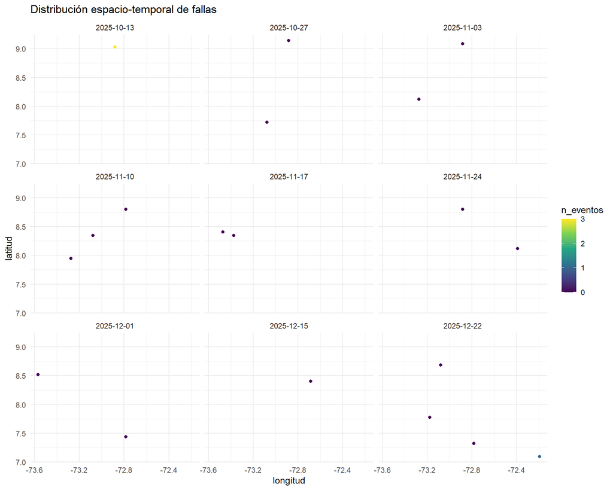

```r
ggplot(panel_semana %>%
         slice_sample(n = 500) %>%
         filter(semana >= as.Date("2025-10-01")), aes(x = longitud, y = latitud)) +
  geom_point(aes(color = n_eventos), size = 1.5) +
  facet_wrap(~semana) +
  scale_color_viridis_c() +
  theme_minimal() +
  labs(title = "Distribución espacio-temporal de fallas")
```

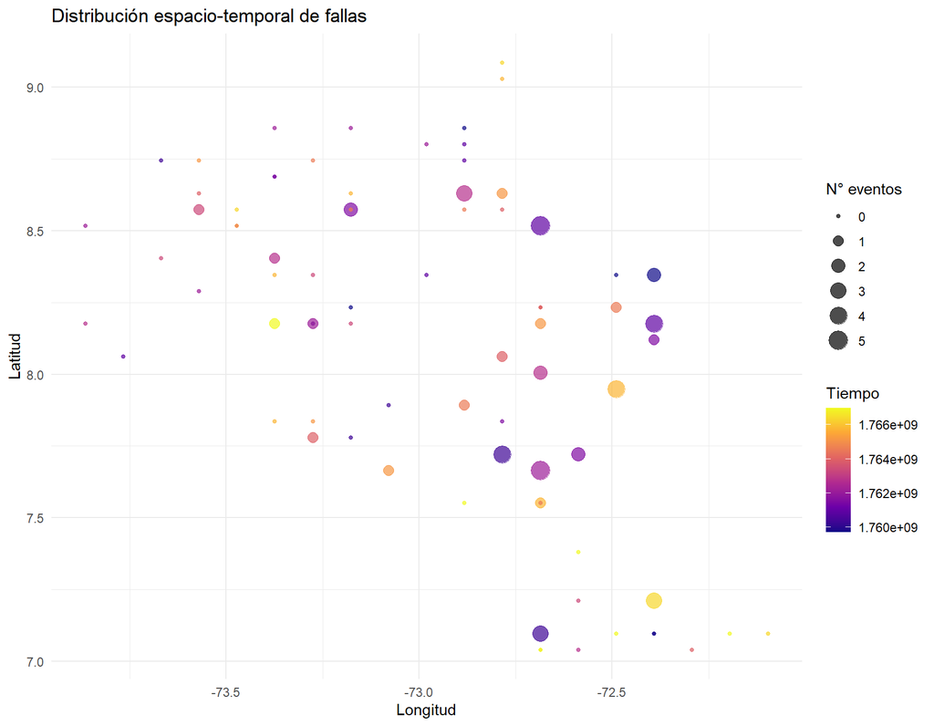

```r
ggplot(
  panel_semana %>%
    slice_sample(n = 2000) %>%
    filter(semana >= as.Date("2025-10-01")),
  aes(x = longitud, y = latitud)
) +
  geom_point(
    aes(
      color = as.numeric(semana),   # tiempo como continuo
      size = n_eventos
    ),
    alpha = 0.7
  ) +
  scale_color_viridis_c(
    option = "plasma",
    name = "Tiempo"
  ) +
  scale_size_continuous(
    range = c(1, 6),
    name = "N° eventos"
  ) +
  theme_minimal() +
  labs(
    title = "Distribución espacio-temporal de fallas",
    x = "Longitud",
    y = "Latitud"
  )
```

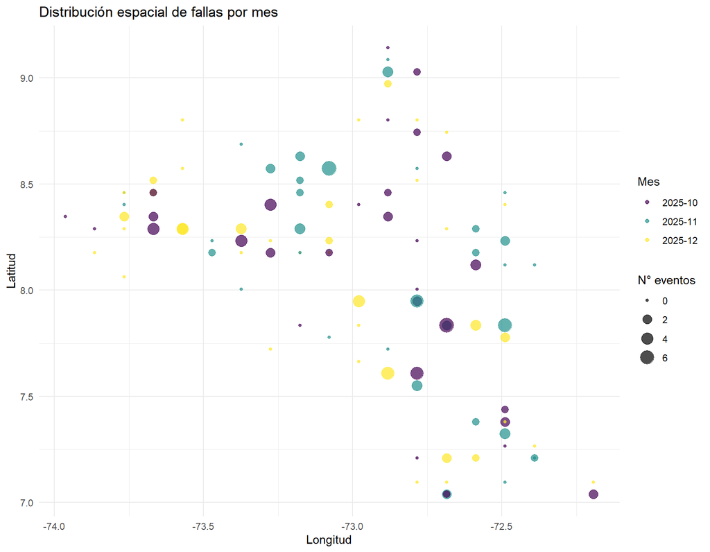

```r
ggplot(
  panel_semana %>%
    slice_sample(n = 2000) %>%
    filter(semana >= as.Date("2025-10-01")) %>%
    mutate(
      mes = format(floor_date(semana, "month"), "%Y-%m")
    ),
  aes(x = longitud, y = latitud)
) +
  geom_point(
    aes(
      color = mes,
      size = n_eventos
    ),
    alpha = 0.7
  ) +
  scale_color_viridis_d(name = "Mes") +
  scale_size_continuous(range = c(1, 6), name = "N° eventos") +
  theme_minimal() +
  labs(
    title = "Distribución espacial de fallas por mes",
    x = "Longitud",
    y = "Latitud"
  )
```

# 7. Animación espacio-temporal (opcional)

Este bloque genera una animación GIF de la evolución espacial de fallas. Se deja como **opcional** (`eval=FALSE` por defecto) porque requiere paquetes adicionales (`gganimate`, `gifski`, `transformr`) y tarda más que el resto del documento — actívalo manualmente si lo necesitas para la presentación.

```r
if (!requireNamespace("gganimate", quietly = TRUE)) install.packages("gganimate")
if (!requireNamespace("gifski", quietly = TRUE)) install.packages("gifski")
if (!requireNamespace("transformr", quietly = TRUE)) install.packages("transformr")
library(gganimate)
```

```r
animacion <- ggplot(
  panel_semana %>%
    slice_sample(n = 3000) %>%
    filter(semana >= as.Date("2025-10-01")),
  aes(x = longitud, y = latitud)
) +
  geom_point(
    aes(
      size = n_eventos,
      color = n_eventos
    ),
    alpha = 0.7
  ) +
  scale_color_viridis_c(name = "Eventos") +
  scale_size(range = c(1, 6)) +
  theme_minimal() +
  labs(
    title = "Semana: {frame_time}",
    x = "Longitud",
    y = "Latitud"
  ) +
  transition_time(semana) +
  ease_aes("linear")

animate(animacion, nframes = 80, fps = 8, width = 800, height = 600)

# Guardado en UBICACION_DATA, no en una ruta fija de usuario
anim_save(file.path(UBICACION_DATA, "fallas_animacion.gif"), animacion)
```

## Versión mejorada (recomendada para presentación)

```r
animacion_pro <- ggplot(
  panel_semana %>%
    slice_sample(n = 3000) %>%
    filter(semana >= as.Date("2025-10-01")),
  aes(x = longitud, y = latitud)
) +
  geom_point(
    aes(
      size = n_eventos,
      color = n_eventos
    ),
    alpha = 0.6
  ) +
  scale_color_viridis_c(option = "plasma") +
  scale_size(range = c(1, 5)) +
  theme_minimal() +
  labs(
    title = "Evolución de fallas | Semana: {frame_time}",
    subtitle = "Tamaño = número de eventos | Color = intensidad",
    x = "Longitud",
    y = "Latitud"
  ) +
  transition_time(semana) +
  shadow_mark(alpha = 0.1) +   # deja "rastro"
  ease_aes("linear")
```

**Interpretación:** la animación permite observar clusters persistentes de fallas, dinámica temporal asociada a condiciones climáticas, zonas críticas recurrentes y posibles patrones de propagación espacial.

# 8. Interpretación técnica

La construcción del panel permite establecer una estructura de datos coherente donde:

- Se alinean variables climáticas y operativas en una misma unidad de análisis
- Se preserva la dimensión espacial mediante cuadrantes
- Se captura la variabilidad temporal a nivel semanal

Este enfoque evita problemas comunes como:

- Explosión de registros por joins a nivel elemento
- Inconsistencias entre escalas de agregación
- Pérdida de interpretabilidad en modelos

Adicionalmente, la variable `falla` define un problema de clasificación binaria, mientras que `n_eventos` permite un enfoque alternativo de conteo (Poisson o modelos de intensidad).

**Nota metodológica importante:** este panel (`panel_semana`) usa `n_eventos` y `duracion_total` en bruto, sin el denominador de usuarios totales por cuadrante. Los documentos de Etapa 4 que consumen este panel (`Etapa4_01`, `Etapa4_02`) definen `SAIFI`/`SAIDI` como aproximaciones provisionales sobre estas variables — **no** la fórmula oficial con `usuarios_totales`/`usuarios_afectados` descrita en el capítulo de metodología. Ver la nota de alcance en esos documentos.